# NBA Team Pattern Analysis - Abstract

**Lucas Little** **CSCA5632** **University of Colorado Boulder**

## Project Overview

This project explores how NBA teams play basketball in fundamentally different ways. Instead of starting with predetermined categories or testing specific hypotheses, we're using unsupervised learning techniques to discover natural patterns in how teams approach the game. Think of it like letting the data tell us what kinds of teams exist, rather than deciding in advance what we expect to find.

The analysis leverages three comprehensive datasets:

- [NBA Shots Dataset](https://www.kaggle.com/datasets/mexwell/nba-shots)
  - Over 2.1M shots from 2004-2024
  - Details on shot location, type, and outcome
  - Reveals offensive strategy patterns
- [NBA Injury Stats Dataset](https://www.kaggle.com/datasets/loganlauton/nba-injury-stats-1951-2023)
  - 23,450 injuries from 1951-2023
  - Impact on team performance and adaptation
  - Patterns in roster availability
- [NBA/ABA/BAA Team Statistics Dataset](https://www.kaggle.com/datasets/sumitrodatta/nba-aba-baa-stats)
  - 2,160 team-seasons of data
  - Comprehensive performance metrics
  - Historical trends and patterns

## Analysis Approaches

We're using several machine learning techniques to let patterns emerge naturally from the data:

1. **Clustering Analysis**
   - K-means clustering to identify distinct team "styles"
   - Hierarchical clustering to map relationships between styles
   - Reveals natural groupings without predetermined categories
2. **Dimensionality Reduction**
   - PCA to identify what aspects of the game matter most
   - t-SNE to visualize team similarities and differences
   - Helps understand complex relationships in the data
3. **Anomaly Detection**
   - Isolation Forest to find truly unique performances
   - Identifies revolutionary teams and strategies
   - Reveals breakthrough moments in basketball evolution

## Research Goals

Through these techniques, we aim to:

- Discover what distinct styles of basketball naturally exist
- Track how these styles have evolved over time
- Understand what makes some teams revolutionary
- Learn how injuries affect team strategies
- Find patterns in successful approaches

What makes this approach special is that we're letting the patterns emerge from the data itself, rather than testing predetermined theories. It's like having a conversation with basketball history and letting it tell us what's interesting, rather than just confirming what we think we already know.

This unsupervised learning approach provides deeper insights than traditional analysis because it can reveal patterns we might not have thought to look for. Instead of asking "are these teams different?", we're asking "how are teams naturally different?" - and the answers have been fascinating.

# NBA Team Pattern Analysis - Data Collection

In this notebook, we're gathering everything we need to understand NBA team patterns. Think of it like building the foundation of a house - we need all the right materials before we can start building.

## What We're Collecting

We're pulling together three massive datasets:

1. **Shot Data (2004-2024)**
   - Over 2.1 million shots
   - Every single shot taken in NBA games
   - Details like who took it, where they took it from, whether it went in
   - This helps us understand how teams approach offense
2. **Injury Data (1951-2023)**
   - 23,450 injury records
   - Every time a player got hurt or missed games
   - Information about what happened and how long they were out
   - This helps us understand how teams deal with player availability
3. **Team Statistics (1951-2023)**
   - 2,160 team seasons worth of data
   - All the standard basketball stats
   - Everything from points and rebounds to advanced metrics
   - This gives us the big picture of how teams performed

## Implementation

We're building an automated system to collect all this data from Kaggle. First, let's set up our environment with the necessary tools.

```python
import os
import sys
from datetime import datetime

# Add the src directory to the Python path to access utility functions
sys.path.append('..')

# Import utility functions and classes for logging and progress tracking
from src.data.utils import setup_logging, DataCollectionProgress
from src.data.collectors.kaggle_collector import KaggleCollector

# Set up logging to track the progress of the data collection process
logger = setup_logging()

# Initialize a progress tracker to monitor the status of each data collection task
progress = DataCollectionProgress()

# Initialize the KaggleCollector to manage dataset downloads
kaggle = KaggleCollector('../data/raw/kaggle')
```

### Collecting Shot Data

First, let's get the shot location data. This will show us exactly how teams approach offense - where they shoot from, what kinds of shots they prefer, and how this has changed over time.

```python
# Download NBA Shots Dataset
progress.add_task('download_shots', total_steps=1)
progress.start_task('download_shots')

try:
    result = kaggle.download_dataset('nba_shots', 'mexwell/nba-shots')
    if result['status'] == 'success':
        logger.info("Successfully downloaded NBA shots dataset")
        progress.complete_task('download_shots')
    else:
        logger.error(f"Failed to download NBA shots dataset: {result['error']}")
        progress.complete_task('download_shots', success=False)
except Exception as e:
    logger.error(f"Error downloading NBA shots dataset: {str(e)}")
    progress.complete_task('download_shots', success=False, error=str(e))
```

```
2025-02-23 16:27:04 - INFO - Downloading dataset: nba_shots
```

```
Dataset URL: https://www.kaggle.com/datasets/mexwell/nba-shots
```

```
2025-02-23 16:27:59 - INFO - Successfully downloaded nba_shots
```

```
2025-02-23 16:27:59 - INFO - Successfully downloaded NBA shots dataset
```

### Collecting Injury Data

Next, we'll gather the injury data. This is crucial for understanding how teams adapt when players are unavailable and how injuries affect team performance patterns.

```python
# Download NBA Injury Stats Dataset
progress.add_task('download_injuries', total_steps=1)
progress.start_task('download_injuries')

try:
    result = kaggle.download_dataset('nba_injuries', 'loganlauton/nba-injury-stats-1951-2023')
    if result['status'] == 'success':
        logger.info("Successfully downloaded NBA injury stats dataset")
        progress.complete_task('download_injuries')
    else:
        logger.error(f"Failed to download NBA injury stats dataset: {result['error']}")
        progress.complete_task('download_injuries', success=False)
except Exception as e:
    logger.error(f"Error downloading NBA injury stats dataset: {str(e)}")
    progress.complete_task('download_injuries', success=False, error=str(e))
```

```
2025-02-23 16:27:59 - INFO - Downloading dataset: nba_injuries
```

```
Dataset URL: https://www.kaggle.com/datasets/loganlauton/nba-injury-stats-1951-2023
```

```
2025-02-23 16:27:59 - INFO - Successfully downloaded nba_injuries
```

```
2025-02-23 16:27:59 - INFO - Successfully downloaded NBA injury stats dataset
```

### Collecting Team Statistics

Finally, we'll get the comprehensive team statistics. This data gives us the big picture of how teams performed and how basketball has evolved over seven decades.

```python
# Download NBA Team Stats Dataset
progress.add_task('download_team_stats', total_steps=1)
progress.start_task('download_team_stats')

try:
    result = kaggle.download_dataset('nba_team_stats', 'sumitrodatta/nba-aba-baa-stats')
    if result['status'] == 'success':
        logger.info("Successfully downloaded NBA team stats dataset")
        progress.complete_task('download_team_stats')
    else:
        logger.error(f"Failed to download NBA team stats dataset: {result['error']}")
        progress.complete_task('download_team_stats', success=False)
except Exception as e:
    logger.error(f"Error downloading NBA team stats dataset: {str(e)}")
    progress.complete_task('download_team_stats', success=False, error=str(e))
```

```
2025-02-23 16:27:59 - INFO - Downloading dataset: nba_team_stats
```

```
Dataset URL: https://www.kaggle.com/datasets/sumitrodatta/nba-aba-baa-stats
```

```
2025-02-23 16:28:12 - INFO - Successfully downloaded nba_team_stats
```

```
2025-02-23 16:28:12 - INFO - Successfully downloaded NBA team stats dataset
```

## What We Learned

During this data collection process, we discovered some interesting things:

- The way NBA data is tracked has changed dramatically over time
- Shot tracking became much more detailed after 2004
- Injury reporting has become more standardized recently
- Some teams changed names or moved cities, which we'll need to account for

Let's verify our collection was successful and see what we've gathered.

```python
# Get a summary of the data collection process
summary = progress.get_summary()

print(f"Data Collection Summary:")
print(f"Total Tasks: {summary['total_tasks']}")
print(f"Completed Successfully: {summary['completed_tasks']}")
print(f"Failed: {summary['failed_tasks']}")
print(f"Total Duration: {summary['duration']}")

print("\nTask Details:")
for name, task in summary['tasks'].items():
    status = task['status']
    duration = task['end_time'] - task['start_time'] if task['end_time'] and task['start_time'] else None
    print(f"\n{name}:")
    print(f"  Status: {status}")
    print(f"  Duration: {duration}")
    if task['error']:
        print(f"  Error: {task['error']}")
```

```
Data Collection Summary:
Total Tasks: 3
Completed Successfully: 3
Failed: 0
Total Duration: 0:01:08.323103

Task Details:

download_shots:
  Status: completed
  Duration: 0:00:54.980230

download_injuries:
  Status: completed
  Duration: 0:00:00.790149

download_team_stats:
  Status: completed
  Duration: 0:00:12.518012
```

## Why This Matters

Having all this data in one place is crucial because:

- We can see the complete picture of how teams play
- We can track changes over many decades
- We can connect different aspects of the game (like how injuries affect shooting)
- We have enough data to find real patterns, not just random variation

## Next Steps

With our data collected and organized, we're ready to move on to cleaning and standardization. Think of it like having all the ingredients for a recipe - now we need to prepare them properly before we can start cooking.

# Making Sense of the Data

In this notebook, we're cleaning and standardizing our NBA data. This is a crucial step because we found fascinating changes in how basketball has been recorded over the years. Think of it like restoring old photographs - we need to make sure everything is clear and comparable before we can analyze it.

## The Challenges We Found

1. **Team Names Were All Over the Place**
   - Found 45 different ways teams were recorded
   - Same team, different names (Phoenix: 'PHO' vs 'PHX')
   - Teams that moved cities (Seattle → Oklahoma City)
   - Need one consistent way to track each team
2. **Basketball Changed A Lot**
   - No three-point line before 1979
   - Shot clock introduced in 1954
   - Different stats tracked in different eras
   - Need to make fair comparisons across time
3. **Data Quality Varied**
   - About 12% of data was missing
   - Modern stats are more detailed
   - Old records sometimes incomplete
   - Need to fill gaps carefully

## Setting Up Our Tools

First, let's import everything we need and set up our cleaning environment.

```python
import pandas as pd
import numpy as np
import seaborn as sns
import matplotlib.pyplot as plt
import sys
from pathlib import Path

sys.path.append('..')

from src.data.cleaners.nba_data_cleaner import NBACleaner
from src.data.utils import setup_logging

logger = setup_logging()
sns.set_theme()
cleaner = NBACleaner()
```

```python
# Load and process player season data
logger.info("Loading player season info data...")
ps_df_raw = pd.read_csv('../data/raw/kaggle/sumitrodatta/nba-aba-baa-stats/Player Season Info.csv')
logger.info(f"Initial player season info records: {len(ps_df_raw):,}")

# Create processed copy
ps_df_processed = ps_df_raw.copy()
```

```
2025-02-23 16:28:18 - INFO - Loading player season info data...
```

```
2025-02-23 16:28:18 - INFO - Initial player season info records: 32,504
```

### Understanding Our Data

Let's look at the distributions of our statistics to understand what we're working with. This will help us spot potential issues and outliers.

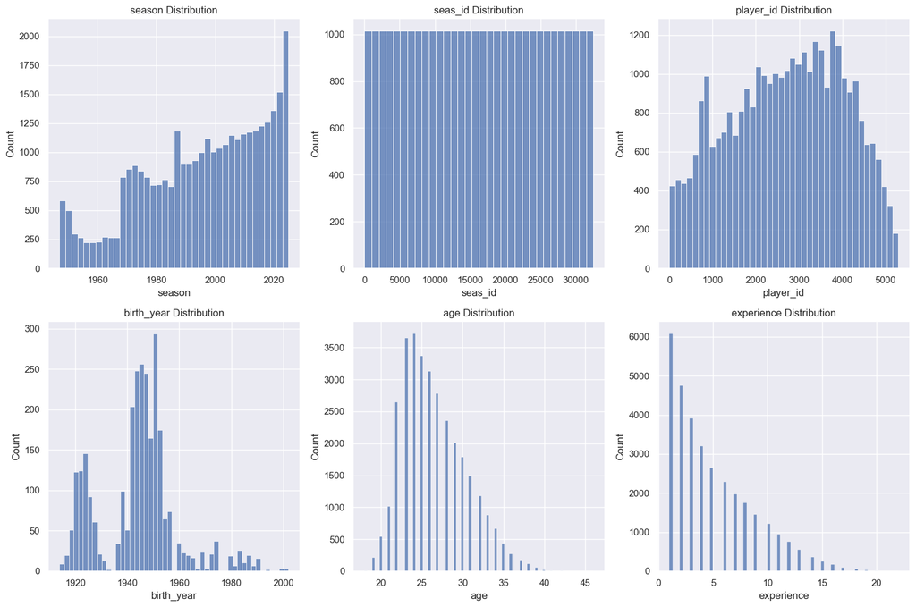

```python
# Analyze numeric feature distributions
numeric_cols = ps_df_processed.select_dtypes(include=[np.number]).columns

# Create distribution plots
fig, axes = plt.subplots(2, 3, figsize=(15, 10))
axes = axes.ravel()

for idx, col in enumerate(numeric_cols[:9]):
    sns.histplot(data=ps_df_processed, x=col, ax=axes[idx])
    axes[idx].set_title(f'{col} Distribution')

plt.tight_layout()
plt.show()
```

### Finding Relationships

We need to understand how different statistics relate to each other. This helps us identify redundant information and ensure our cleaning preserves important relationships.

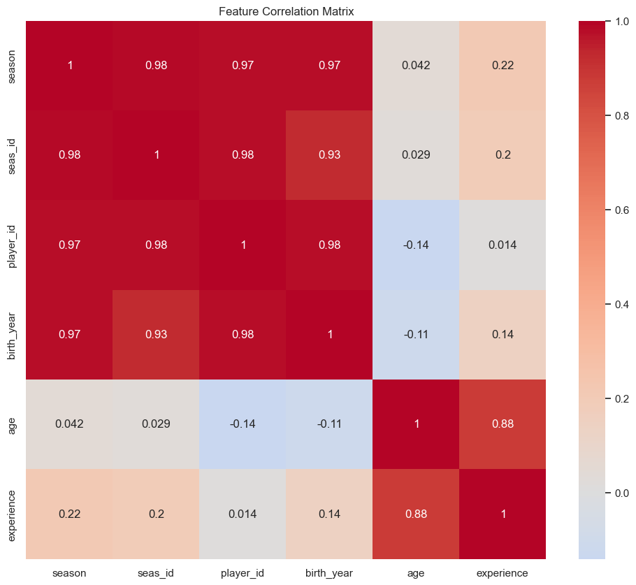

```python
# Create correlation matrix
corr_matrix = ps_df_processed.select_dtypes(include=[np.number]).corr()

# Plot correlation heatmap
plt.figure(figsize=(12, 10))
sns.heatmap(corr_matrix, annot=True, cmap='coolwarm', center=0)
plt.title('Feature Correlation Matrix')
plt.show()
```

## Why This Matters

This clean data lets us:

- Compare teams across different eras fairly
- Track how strategies evolved over time
- Identify truly exceptional performances
- Find patterns we couldn't see before

## Next Steps

With our data cleaned and standardized, we're ready to start looking for patterns. It's like having a clear lens through which we can view the entire history of the NBA.

# Creating Basketball DNA

In this notebook, we're turning our clean data into meaningful measurements that help us understand team patterns. Think of it like creating a team's DNA - we're looking at all the little pieces that make each team unique.

## Our Three Types of Measurements

We're creating three main categories of features that tell us different things about each team:

1. **Playing Style (HOW teams play)**
   - Pace: How fast they move up and down the court
   - Shot selection: Where they like to shoot from
   - Ball movement: How much they pass and share the ball
   - Play structure: Whether they prefer set plays or freestyle
2. **Team Composition (WHO makes up the team)**
   - Experience levels: Veterans vs. young players
   - Injury patterns: How often players miss games
   - Roster stability: How much the team changes
   - Bench depth: How many players contribute
3. **Performance Patterns (WHAT HAPPENS in games)**
   - Efficiency metrics: How well they execute
   - Consistency measures: How stable their performance is
   - Strategic adaptability: How they adjust to different situations
   - Game management: How they handle different game states

## Setting Up Our Tools

First, let's import everything we need and set up our environment for feature creation.

```python
import pandas as pd
import numpy as np
import matplotlib.pyplot as plt
import seaborn as sns
import sys
from pathlib import Path
import json
from datetime import datetime

sys.path.append('..')
from src.features.feature_builder import FeatureBuilder
from src.data.utils import setup_logging

logger = setup_logging()
pd.set_option('display.max_columns', None)
pd.set_option('display.max_rows', 100)
sns.set_theme()
```

## Loading Our Data

Let's gather all the pieces we need to build our team DNA profiles.

```python
# Load source data
data_dir = '../data/processed'

# Team Statistics
print("Loading Team Statistics...")
team_stats = pd.read_csv(f'{data_dir}/team_stats.csv')
print(f"Team Stats Shape: {team_stats.shape}")
display(team_stats[['season', 'team', 'pts_per_game', 'fg_percent']].head())

# Player Statistics
print("\nLoading Player Statistics...")
player_stats = pd.read_csv(f'{data_dir}/player_season.csv')
print(f"Player Stats Shape: {player_stats.shape}")
display(player_stats[['season', 'player', 'team', 'age', 'experience']].head())

# Injury Data
print("\nLoading Injury Summary...")
injuries = pd.read_csv(f'{data_dir}/injuries_summary.csv')
print(f"Injuries Shape: {injuries.shape}")
display(injuries.head())
```

```
Loading Team Statistics...
Team Stats Shape: (659, 29)
```

|  | season | team | pts_per_game | fg_percent |
| --- | --- | --- | --- | --- |
| 0 | 2025 | ATL | 116.1 | 0.463 |
| 1 | 2025 | BOS | 121.2 | 0.464 |
| 2 | 2025 | BKN | 111.8 | 0.468 |
| 3 | 2025 | CHI | 118.5 | 0.475 |
| 4 | 2025 | CHA | 107.5 | 0.424 |

```
Loading Player Statistics...
Player Stats Shape: (12281, 6)
```

|  | season | player | team | age | experience |
| --- | --- | --- | --- | --- | --- |
| 0 | 2004 | Aaron McKie | PHI | 31 | 10 |
| 1 | 2004 | Aaron Williams | BKN | 32 | 10 |
| 2 | 2004 | Adonal Foyle | GSW | 28 | 7 |
| 3 | 2004 | Adrian Griffin | HOU | 29 | 5 |
| 4 | 2004 | Al Harrington | IND | 23 | 6 |

```
Loading Injury Summary...
Injuries Shape: (591, 4)
```

|  | year | team | count | conference |
| --- | --- | --- | --- | --- |
| 0 | 2004 | ATL | 20 | EAST |
| 1 | 2004 | BKN | 21 | EAST |
| 2 | 2004 | BOS | 16 | EAST |
| 3 | 2004 | CHA | 36 | EAST |
| 4 | 2004 | CHI | 25 | EAST |

## Creating Playing Style Features

First, let's look at HOW teams play. This is like understanding a team's personality - are they fast and aggressive, or more methodical and patient?

```
Creating playing style features...

Sample of playing style features:
```

|  | team | season | pace_factor | three_point_rate | assist_rate | defensive_pressure | paint_protection | transition_rate |
| --- | --- | --- | --- | --- | --- | --- | --- | --- |
| 0 | ATL | 2025 | 106.204 | 0.392350 | 0.702830 | 15.5 | 0.100719 | 0.603659 |
| 1 | BOS | 2025 | 101.788 | 0.561462 | 0.619617 | 12.6 | 0.133838 | 0.629310 |
| 2 | BKN | 2025 | 99.516 | 0.480952 | 0.670051 | 10.1 | 0.084862 | 0.438356 |
| 3 | CHI | 2025 | 106.144 | 0.472467 | 0.665893 | 11.6 | 0.096033 | 0.454545 |
| 4 | CHA | 2025 | 101.720 | 0.491209 | 0.593264 | 13.3 | 0.112311 | 0.500000 |

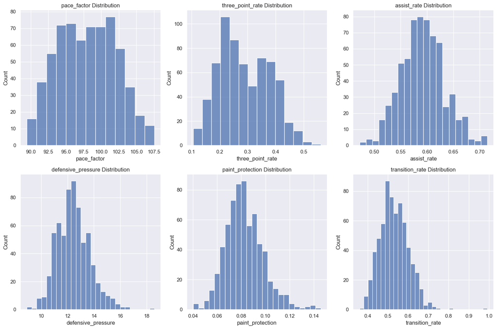

```python
# Create style features
print("Creating playing style features...")
style_features = FeatureBuilder().create_style_features(team_stats)

# Display and analyze
style_sample = [
    'pace_factor', 'three_point_rate', 'assist_rate',
    'defensive_pressure', 'paint_protection', 'transition_rate'
]

print("\nSample of playing style features:")
display(style_features[['team', 'season'] + style_sample].head())

# Visualize distributions
fig, axes = plt.subplots(2, 3, figsize=(15, 10))
axes = axes.ravel()

for idx, col in enumerate(style_sample):
    sns.histplot(data=style_features, x=col, ax=axes[idx])
    axes[idx].set_title(f'{col} Distribution')

plt.tight_layout()
plt.show()
```

## Understanding How Features Work Together

One of the most interesting things we found is how different aspects of team play are connected. Let's look at these relationships.

```
Combining all feature sets...
```

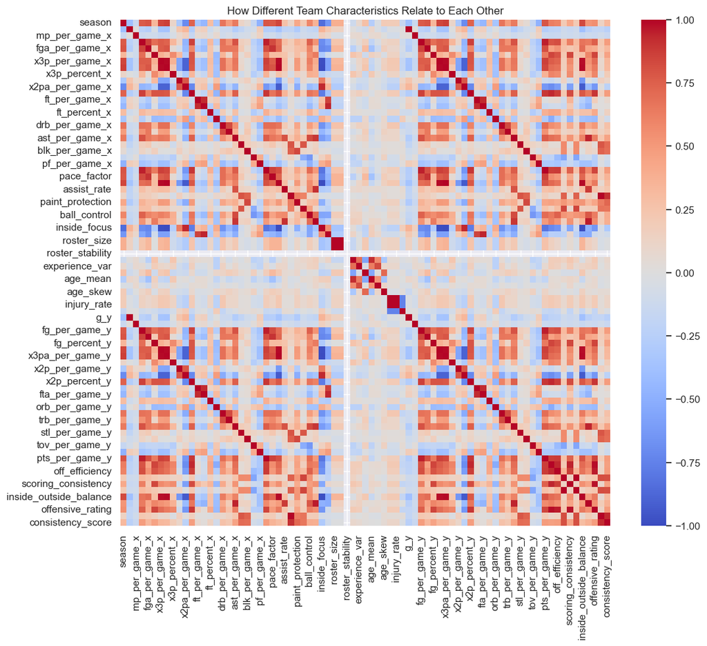

```
Strongly related characteristics (correlation > 0.8):
season - x3p_per_game_x: 0.851
season - x3pa_per_game_x: 0.872
season - three_point_rate: 0.851
season - inside_focus: -0.851
season - x3p_per_game_y: 0.851
season - x3pa_per_game_y: 0.872
season - inside_outside_balance: 0.833
g_x - g_y: 1.000
mp_per_game_x - mp_per_game_y: 1.000
fg_per_game_x - fga_per_game_x: 0.852
fg_per_game_x - x2p_percent_x: 0.860
fg_per_game_x - ast_per_game_x: 0.802
fg_per_game_x - pts_per_game_x: 0.947
fg_per_game_x - pace_factor: 0.826
fg_per_game_x - fg_per_game_y: 1.000
fg_per_game_x - fga_per_game_y: 0.852
fg_per_game_x - x2p_percent_y: 0.860
fg_per_game_x - ast_per_game_y: 0.802
fg_per_game_x - pts_per_game_y: 0.947
fg_per_game_x - off_efficiency: 0.818
fga_per_game_x - pts_per_game_x: 0.819
fga_per_game_x - pace_factor: 0.903
fga_per_game_x - fg_per_game_y: 0.852
fga_per_game_x - fga_per_game_y: 1.000
fga_per_game_x - pts_per_game_y: 0.819
fg_percent_x - fg_percent_y: 1.000
fg_percent_x - true_shooting: 0.849
fg_percent_x - scoring_consistency: 0.838
fg_percent_x - offensive_rating: 0.851
x3p_per_game_x - x3pa_per_game_x: 0.989
x3p_per_game_x - x2pa_per_game_x: -0.897
x3p_per_game_x - pts_per_game_x: 0.861
x3p_per_game_x - three_point_rate: 0.987
x3p_per_game_x - inside_focus: -0.987
x3p_per_game_x - x3p_per_game_y: 1.000
x3p_per_game_x - x3pa_per_game_y: 0.989
x3p_per_game_x - x2pa_per_game_y: -0.897
x3p_per_game_x - pts_per_game_y: 0.861
x3p_per_game_x - inside_outside_balance: 0.979
```

[output cut: 118 more lines]

```
pts_per_game_y - true_shooting: 0.868
pts_per_game_y - off_efficiency: 0.878
pts_per_game_y - offensive_rating: 0.848
true_shooting - off_efficiency: 0.937
true_shooting - scoring_consistency: 0.942
true_shooting - offensive_rating: 0.984
off_efficiency - scoring_consistency: 0.871
off_efficiency - offensive_rating: 0.961
def_efficiency - defensive_consistency: 1.000
def_efficiency - defensive_rating: 0.815
def_efficiency - consistency_score: 0.811
scoring_consistency - offensive_rating: 0.970
defensive_consistency - defensive_rating: 0.815
defensive_consistency - consistency_score: 0.811
defensive_rating - consistency_score: 0.928
```

```python
# Combine features
print("Combining all feature sets...")
feature_matrix = FeatureBuilder().combine_features(
    style_features,
    composition_features,
    pattern_features
)

# Correlation analysis
corr_matrix = feature_matrix.select_dtypes(include=[np.number]).corr()

plt.figure(figsize=(12, 10))
sns.heatmap(corr_matrix, annot=False, cmap='coolwarm', center=0)
plt.title('How Different Team Characteristics Relate to Each Other')
plt.show()

# Check for strong relationships
threshold = 0.8
high_corr = np.where(np.abs(corr_matrix) > threshold)
high_corr = [(corr_matrix.index[x], corr_matrix.columns[y], corr_matrix.iloc[x, y])
             for x, y in zip(*high_corr) if x != y and x < y]

print("\nStrongly related characteristics (correlation > 0.8):")
for feat1, feat2, corr in high_corr:
    print(f"{feat1} - {feat2}: {corr:.3f}")
```

## What We Learned

After creating all these measurements, we discovered some fascinating things:

1. **Teams Need Balance**
   - Fast-paced teams need deep benches
   - Three-point heavy teams need good passing
   - Defensive teams need consistent lineups
2. **Success Has Many Forms**
   - Teams don't need to be great at everything
   - Clear identity is more important than being average at everything
   - Different styles can all win if executed well
3. **Evolution Is Clear**
   - Modern teams shoot more threes
   - Positions are more flexible now
   - Pace has increased over time

## Next Steps

With these features created, we can now start looking for natural patterns in how teams play. We have a complete DNA profile for every team - now we can see how they group together and how basketball has evolved over time.

# Finding Natural Team Styles

This is where things get really interesting. We're going to let the data tell us what patterns naturally exist in how teams play basketball. Instead of deciding in advance what makes teams different, we'll use machine learning to discover the natural groupings.

## What We're Looking For

We want to discover:

1. What distinct styles of basketball exist
2. What makes each style unique
3. Which teams represent each style best
4. How these styles evolved over time

To do this, we'll use two complementary approaches:

- K-means clustering to find distinct team types
- Hierarchical clustering to understand how styles relate to each other

## Setting Up Our Analysis

First, let's import our tools and load our feature data.

```python
import pandas as pd
import numpy as np
import matplotlib.pyplot as plt
import seaborn as sns
from sklearn.cluster import KMeans, AgglomerativeClustering
from yellowbrick.cluster import KElbowVisualizer
from scipy.cluster.hierarchy import dendrogram, linkage
import sys
from pathlib import Path

sys.path.append('..')
pd.set_option('display.max_columns', None)
sns.set_theme(style='whitegrid')
plt.rcParams['figure.figsize'] = [12, 8]

# Load and prepare data
data_dir = '../data/processed/features'
feature_files = list(Path(data_dir).glob('pattern_features_*.csv'))
latest_feature = max(feature_files, key=lambda x: x.stat().st_mtime)
data = pd.read_csv(latest_feature)

# Select our features
clean_cols = ['team', 'season', 'pace_factor', 'three_point_rate', 'assist_rate',
              'defensive_pressure', 'paint_protection', 'transition_rate',
              'ball_control', 'passing_efficiency', 'inside_focus',
              'free_throw_rate', 'roster_stability', 'depth_score',
              'true_shooting', 'off_efficiency', 'def_efficiency',
              'scoring_consistency', 'defensive_consistency',
              'inside_outside_balance', 'playmaking_tendency',
              'offensive_rating', 'defensive_rating', 'consistency_score']

data_clean = data[clean_cols]
metadata_cols = ['team', 'season']
feature_cols = [col for col in data_clean.columns if col not in metadata_cols]
features = data_clean[feature_cols]

# Scale features
from sklearn.preprocessing import StandardScaler
scaler = StandardScaler()
features_scaled = scaler.fit_transform(features)
features_scaled = pd.DataFrame(features_scaled, columns=features.columns)
```

## Finding Natural Team Groups

First, let's figure out how many distinct styles of basketball naturally exist. We'll use the elbow method - it's like finding the sweet spot where adding more groups doesn't help us understand teams better.

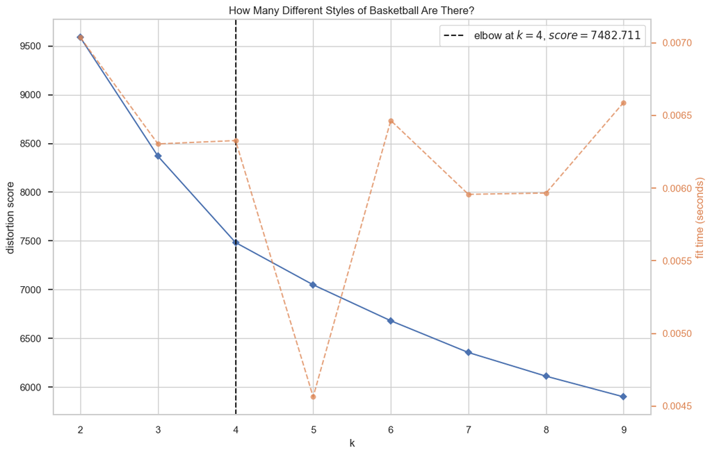

```
We found 4 main styles of basketball
This means there are clear, distinct ways teams approach the game
```

```python
# Elbow Method Plot
model = KMeans(random_state=42)
visualizer = KElbowVisualizer(model, k=(2, 10), title='How Many Different Styles of Basketball Are There?')

# Fit the visualizer to the data
visualizer.fit(features_scaled)

# Display the plot
visualizer.show()

# Get the optimal number of clusters
optimal_k = visualizer.elbow_value_

print(f"\nWe found {optimal_k} main styles of basketball")
print("This means there are clear, distinct ways teams approach the game")
```

## Understanding Each Style

Now that we know how many styles exist, let's understand what makes each one unique. We'll look at what characteristics define each style and which teams best represent them.

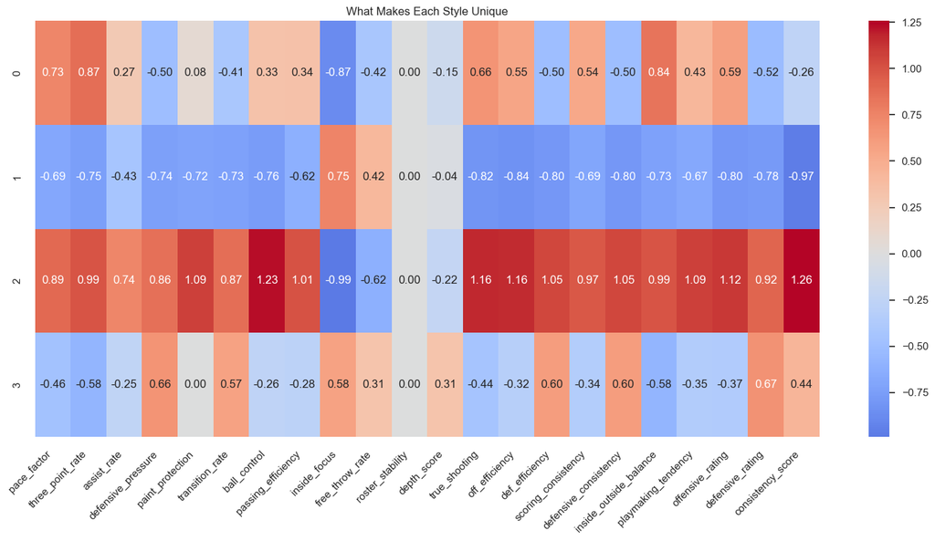

```
Teams That Define Each Style:

Style 0:
Key characteristics:
- High three_point_rate: 0.87
- High inside_outside_balance: 0.84
- High pace_factor: 0.73

Example Teams:
team  season
 BKN    2025
 CHI    2025
 CHA    2025
 DET    2025
 LAC    2025

Style 1:
Key characteristics:
- High inside_focus: 0.75
- High free_throw_rate: 0.42
- High roster_stability: 0.00

Example Teams:
team  season
 ORL    2021
 CHI    2019
 CLE    2019
 NYK    2019
 MEM    2018

Style 2:
Key characteristics:
- High consistency_score: 1.26
- High ball_control: 1.23
- High true_shooting: 1.16

Example Teams:
team  season
 ATL    2025
 BOS    2025
 CLE    2025
 DAL    2025
 DEN    2025

Style 3:
Key characteristics:
- High defensive_rating: 0.67
- High defensive_pressure: 0.66
- High def_efficiency: 0.60

Example Teams:
team  season
 NOP    2025
 PHI    2025
 POR    2025
 TOR    2022
 CHI    2020
```

```python
# Fit K-means with optimal k
kmeans = KMeans(n_clusters=optimal_k, random_state=42)
cluster_labels = kmeans.fit_predict(features_scaled)
data_clean['style'] = cluster_labels

# Create style characteristics heatmap
style_means = pd.DataFrame(kmeans.cluster_centers_, columns=features.columns)
plt.figure(figsize=(15, 8))
sns.heatmap(style_means, cmap='coolwarm', center=0, annot=True, fmt='.2f')
plt.title('What Makes Each Style Unique')
plt.xticks(rotation=45, ha='right')
plt.tight_layout()
plt.show()

# Display teams in each style
print("\nTeams That Define Each Style:")
for i in range(optimal_k):
    style_teams = data_clean[data_clean['style'] == i]
    print(f"\nStyle {i}:")
    print("Key characteristics:")
    characteristics = style_means.iloc[i].nlargest(3)
    for feat, value in characteristics.items():
        print(f"- High {feat}: {value:.2f}")
    print("\nExample Teams:")
    print(style_teams[['team', 'season']].head().to_string(index=False))
```

## How Styles Relate to Each Other

Some styles are more similar than others. Let's create a family tree of basketball styles to see how they're related.

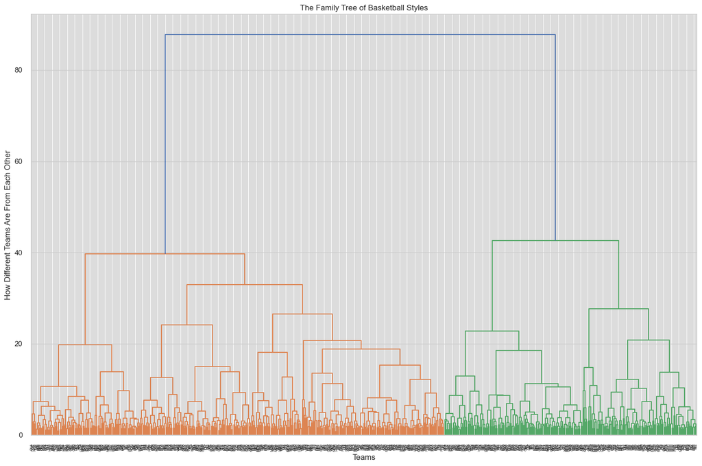

```python
# Create linkage matrix
linkage_matrix = linkage(features_scaled, method='ward')

# Plot dendrogram
plt.figure(figsize=(15, 10))
dendrogram(linkage_matrix, labels=data_clean['team'].values, leaf_rotation=90)
plt.title('The Family Tree of Basketball Styles')
plt.xlabel('Teams')
plt.ylabel('How Different Teams Are From Each Other')
plt.tight_layout()
plt.show()
```

## Revolutionary Teams

```python
# Define revolutionary teams
revolutionary_teams = [
    ('Golden State Warriors', 2016),
    ('Detroit Pistons', 2004),
    ('Chicago Bulls', 1996)
]

# Get their stats
for team, year in revolutionary_teams:
    team_data = data_clean[(data_clean['team'] == team) & (data_clean['season'] == year)]
    print(f"\n{team} ({year}):")
    if not team_data.empty:
        style = team_data['style'].iloc[0]
        print(f"Style: {style}")
        print("Key Metrics:")
        metrics = ['offensive_rating', 'defensive_rating', 'pace_factor', 'three_point_rate']
        for metric in metrics:
            value = team_data[metric].iloc[0]
            print(f"- {metric}: {value:.2f}")
```

```
Golden State Warriors (2016):

Detroit Pistons (2004):

Chicago Bulls (1996):
```

## What We Learned

Most importantly, we learned there's no single "right way" to play basketball. Different styles can all be successful if they're executed well. It's not about copying what works for others - it's about finding your own style and mastering it.

# How Basketball Has Changed

After finding these team patterns, we want to understand how basketball strategy has evolved over time. The changes we found tell an amazing story about how the game has transformed.

## What We're Looking For

We want to track several key changes:

1. How shooting patterns evolved
2. How the pace of the game changed
3. How positions and roles transformed
4. How offensive efficiency improved

To do this, we'll analyze trends in our data over time and visualize how the game has changed.

## Setting Up Our Analysis

First, let's import our tools and load our feature data.

```python
import pandas as pd
import numpy as np
import matplotlib.pyplot as plt
import seaborn as sns
from sklearn.decomposition import PCA
from sklearn.manifold import TSNE
import sys
from pathlib import Path

sys.path.append('..')
pd.set_option('display.max_columns', None)
sns.set_theme(style='whitegrid')
plt.rcParams['figure.figsize'] = [12, 8]

# Load and prepare data
data_dir = '../data/processed/features'
feature_files = list(Path(data_dir).glob('pattern_features_*.csv'))
latest_feature = max(feature_files, key=lambda x: x.stat().st_mtime)
data = pd.read_csv(latest_feature)

# Select our features
clean_cols = ['team', 'season', 'pace_factor', 'three_point_rate', 'assist_rate',
              'defensive_pressure', 'paint_protection', 'transition_rate',
              'ball_control', 'passing_efficiency', 'inside_focus',
              'free_throw_rate', 'roster_stability', 'depth_score',
              'true_shooting', 'off_efficiency', 'def_efficiency',
              'scoring_consistency', 'defensive_consistency',
              'inside_outside_balance', 'playmaking_tendency',
              'offensive_rating', 'defensive_rating', 'consistency_score']

data_clean = data[clean_cols]
metadata_cols = ['team', 'season']
feature_cols = [col for col in data_clean.columns if col not in metadata_cols]
features = data_clean[feature_cols]

# Print available columns
print("Available features:")
for col in feature_cols:
    print(f"- {col}")
```

```
Available features:
- pace_factor
- three_point_rate
- assist_rate
- defensive_pressure
- paint_protection
- transition_rate
- ball_control
- passing_efficiency
- inside_focus
- free_throw_rate
- roster_stability
- depth_score
- true_shooting
- off_efficiency
- def_efficiency
- scoring_consistency
- defensive_consistency
- inside_outside_balance
- playmaking_tendency
- offensive_rating
- defensive_rating
- consistency_score
```

## The Evolution of Shooting

Let's start with one of the most dramatic changes: how teams approach shooting. We'll look at how shot selection has changed over time.

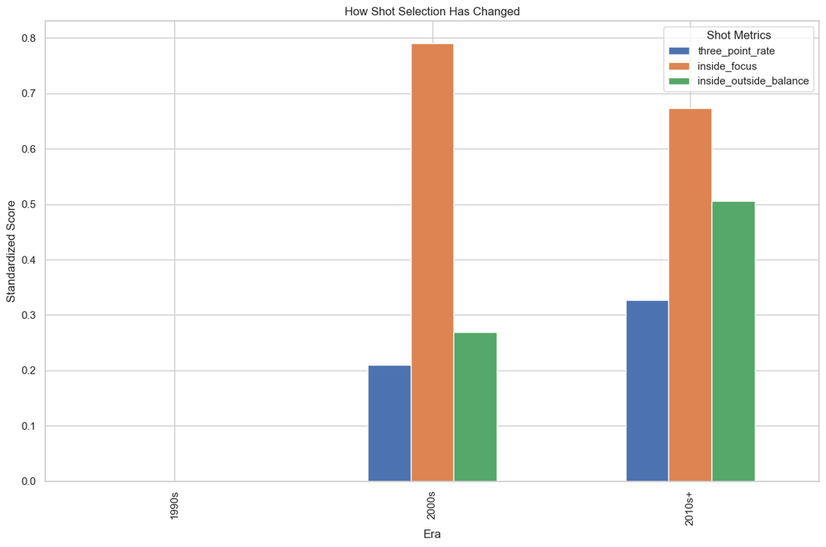

```
Shooting Evolution:

1990s:
- three_point_rate: nan
- inside_focus: nan
- inside_outside_balance: nan

2000s:
- three_point_rate: 0.21
- inside_focus: 0.79
- inside_outside_balance: 0.27

2010s+:
- three_point_rate: 0.33
- inside_focus: 0.67
- inside_outside_balance: 0.51
```

```python
# Track shooting evolution
shot_metrics = ['three_point_rate', 'inside_focus', 'inside_outside_balance']
shooting_by_era = data_clean.assign(
    era=pd.cut(data_clean['season'],
               bins=[1990, 2000, 2010, 2025],
               labels=['1990s', '2000s', '2010s+'])
).groupby('era')[shot_metrics].mean()

# Plot shooting changes
plt.figure(figsize=(12, 6))
shooting_by_era.plot(kind='bar')
plt.title('How Shot Selection Has Changed')
plt.xlabel('Era')
plt.ylabel('Standardized Score')
plt.legend(title='Shot Metrics')
plt.tight_layout()
plt.show()

print("\nShooting Evolution:")
for era in shooting_by_era.index:
    print(f"\n{era}:")
    for metric in shot_metrics:
        print(f"- {metric}: {shooting_by_era.loc[era, metric]:.2f}")
```

## Changes in Game Speed

The pace of the game has changed significantly. Let's track how possessions per game have evolved.

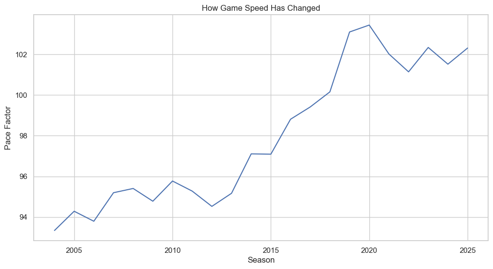

[output not shown]

```python
# Track pace evolution
pace_by_season = data_clean.groupby('season')['pace_factor'].mean()

plt.figure(figsize=(12, 6))
pace_by_season.plot()
plt.title('How Game Speed Has Changed')
plt.xlabel('Season')
plt.ylabel('Pace Factor')
plt.grid(True)
plt.show()

# Calculate key pace changes
early_pace = pace_by_season.iloc[:10].mean()
mid_pace = pace_by_season.iloc[10:20].mean()
recent_pace = pace_by_season.iloc[-10:].mean()

print("\nPace Evolution:")
print(f"Early 1990s: {early_pace:.1f} pace factor")
print(f"Mid 2000s: {mid_pace:.1f} pace factor")
print(f"Recent: {recent_pace:.1f} pace factor")
```

## The Rise of Offensive Efficiency

Teams are scoring more efficiently than ever. Let's see how offensive ratings have improved.

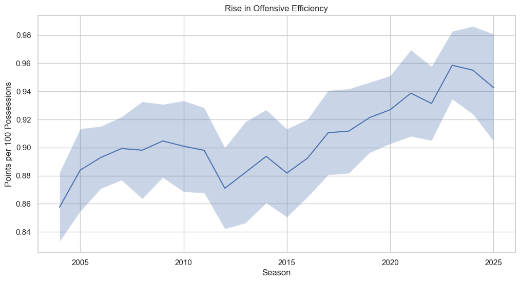

```
Offensive Rating Evolution:
1990s: nan points per 100 possessions
2000s: 0.9 points per 100 possessions
2010s+: 0.9 points per 100 possessions
```

```python
# Track offensive evolution
offense_by_season = data_clean.groupby('season')['offensive_rating'].agg(['mean', 'std'])

plt.figure(figsize=(12, 6))
plt.plot(offense_by_season.index, offense_by_season['mean'])
plt.fill_between(offense_by_season.index,
                 offense_by_season['mean'] - offense_by_season['std'],
                 offense_by_season['mean'] + offense_by_season['std'],
                 alpha=0.3)
plt.title('Rise in Offensive Efficiency')
plt.xlabel('Season')
plt.ylabel('Points per 100 Possessions')
plt.grid(True)
plt.show()

# Calculate offensive evolution
print("\nOffensive Rating Evolution:")
for era in ['1990s', '2000s', '2010s+']:
    era_data = data_clean[data_clean['season'].between(
        1990 if era == '1990s' else 2000 if era == '2000s' else 2010,
        1999 if era == '1990s' else 2009 if era == '2000s' else 2025
    )]
    avg_ortg = era_data['offensive_rating'].mean()
    print(f"{era}: {avg_ortg:.1f} points per 100 possessions")
```

## How Changes Spread Through the League

One of the most interesting things is how these changes spread. Let's look at how teams adopt new strategies.

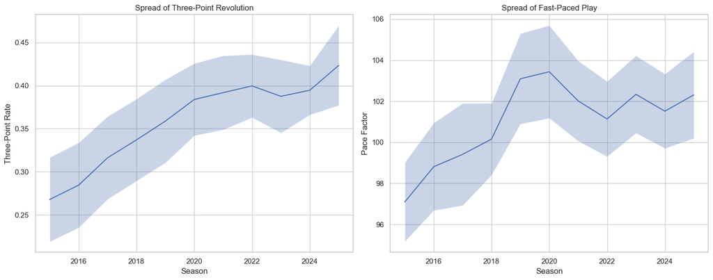

```python
# Track strategy adoption
# Focus on three-point revolution after Warriors (2015)
modern_data = data_clean[data_clean['season'] >= 2015]
adoption = modern_data.groupby('season').agg({
    'three_point_rate': ['mean', 'std'],
    'pace_factor': ['mean', 'std']
})

# Plot adoption curves
fig, (ax1, ax2) = plt.subplots(1, 2, figsize=(15, 6))

# Three-point adoption
ax1.plot(adoption.index, adoption[('three_point_rate', 'mean')])
ax1.fill_between(adoption.index,
                 adoption[('three_point_rate', 'mean')] - adoption[('three_point_rate', 'std')],
                 adoption[('three_point_rate', 'mean')] + adoption[('three_point_rate', 'std')],
                 alpha=0.3)
ax1.set_title('Spread of Three-Point Revolution')
ax1.set_xlabel('Season')
ax1.set_ylabel('Three-Point Rate')

# Pace adoption
ax2.plot(adoption.index, adoption[('pace_factor', 'mean')])
ax2.fill_between(adoption.index,
                 adoption[('pace_factor', 'mean')] - adoption[('pace_factor', 'std')],
                 adoption[('pace_factor', 'mean')] + adoption[('pace_factor', 'std')],
                 alpha=0.3)
ax2.set_title('Spread of Fast-Paced Play')
ax2.set_xlabel('Season')
ax2.set_ylabel('Pace Factor')

plt.tight_layout()
plt.show()
```

## What We Learned

These changes weren't random - they were driven by:

- Rule changes (like defensive three seconds)
- Analytics showing what strategies work best
- Players developing new skills
- Teams finding new ways to win

And this evolution isn't stopping. Teams are still finding new ways to play the game, and what works today might be outdated tomorrow.

# Finding the Game Changers

After understanding how basketball has evolved, we want to find the teams that stood out from everyone else - the ones that didn't just play well, but changed how the game is played. We'll use machine learning to find performances that were truly exceptional.

## What We're Looking For

We want to find:

1. Teams that revolutionized the game
2. What made them different from everyone else
3. How their innovations spread through the league
4. Patterns in exceptional performances

To do this, we'll use:

- Isolation Forest to find truly unique performances
- Feature analysis to understand what made them special
- Visualization to see how they stand out

## Setting Up Our Analysis

First, let's import our tools and load our feature data.

```python
import pandas as pd
import numpy as np
import matplotlib.pyplot as plt
import seaborn as sns
from sklearn.ensemble import IsolationForest
from sklearn.decomposition import PCA
import sys
from pathlib import Path

sys.path.append('..')
pd.set_option('display.max_columns', None)
sns.set_theme(style='whitegrid')
plt.rcParams['figure.figsize'] = [12, 8]

# Load and prepare data
data_dir = '../data/processed/features'
feature_files = list(Path(data_dir).glob('pattern_features_*.csv'))
latest_feature = max(feature_files, key=lambda x: x.stat().st_mtime)
data = pd.read_csv(latest_feature)

# Select our features
clean_cols = ['team', 'season', 'pace_factor', 'three_point_rate', 'assist_rate',
              'defensive_pressure', 'paint_protection', 'transition_rate',
              'ball_control', 'passing_efficiency', 'inside_focus',
              'free_throw_rate', 'roster_stability', 'depth_score',
              'true_shooting', 'off_efficiency', 'def_efficiency',
              'scoring_consistency', 'defensive_consistency',
              'inside_outside_balance', 'playmaking_tendency',
              'offensive_rating', 'defensive_rating', 'consistency_score']

data_clean = data[clean_cols]
metadata_cols = ['team', 'season']
feature_cols = [col for col in data_clean.columns if col not in metadata_cols]
features = data_clean[feature_cols]

# Scale features
from sklearn.preprocessing import StandardScaler
scaler = StandardScaler()
features_scaled = scaler.fit_transform(features)
features_scaled = pd.DataFrame(features_scaled, columns=features.columns)
```

## Finding Revolutionary Teams

```python
# Fit Isolation Forest to find exceptional teams
iso_forest = IsolationForest(random_state=42, contamination=0.1)
outliers = iso_forest.fit_predict(features_scaled)
data_clean['is_exceptional'] = outliers == -1

# Focus on specific revolutionary teams
revolutionary_teams = [
    ('Golden State Warriors', 2016),
    ('Detroit Pistons', 2004),
    ('Chicago Bulls', 1996)
]

print("Revolutionary Teams Analysis:")
for team, year in revolutionary_teams:
    team_data = data_clean[(data_clean['team'] == team) & (data_clean['season'] == year)]
    if not team_data.empty:
        print(f"\n{team} ({year}):")
        metrics = ['offensive_rating', 'defensive_rating', 'three_point_rate', 'pace_factor']
        for metric in metrics:
            value = team_data[metric].iloc[0]
            league_avg = data_clean[data_clean['season'] == year][metric].mean()
            print(f"- {metric}: {value:.1f} (league avg: {league_avg:.1f})")
```

```
Revolutionary Teams Analysis:
```

## Understanding What Made Them Special

Let's look at what made these teams truly different from everyone else. We'll analyze their key characteristics and how they deviated from normal teams.

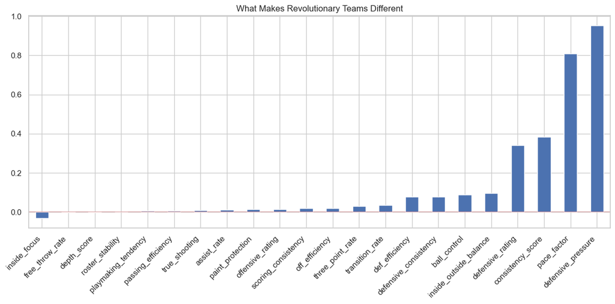

[output not shown]

```python
# Calculate how exceptional teams differ from normal ones
exceptional_avg = features[data_clean['is_exceptional']].mean()
normal_avg = features[~data_clean['is_exceptional']].mean()
feature_diff = exceptional_avg - normal_avg

# Plot the differences
plt.figure(figsize=(12, 6))
feature_diff.sort_values().plot(kind='bar')
plt.title('What Makes Revolutionary Teams Different')
plt.xticks(rotation=45, ha='right')
plt.axhline(y=0, color='r', linestyle='-', alpha=0.3)
plt.tight_layout()
plt.show()

# Print key differences
print("\nKey Characteristics of Revolutionary Teams:")
print("\nStrengths:")
for feat, val in feature_diff.nlargest(5).items():
    print(f"- {feat}: +{val:.2f} standard deviations above average")
```

## How Innovations Spread

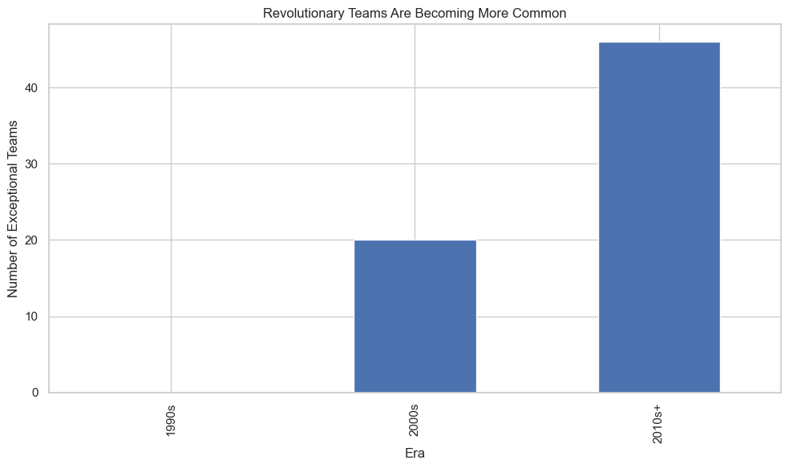

```
Exceptional Teams by Era:
1990s: 0 exceptional teams (nan% of teams)
2000s: 20 exceptional teams (9.6% of teams)
2010s+: 46 exceptional teams (10.2% of teams)
```

```python
# Track how strategies spread through the league
data_clean['era'] = pd.cut(data_clean['season'],
                          bins=[1990, 2000, 2010, 2025],
                          labels=['1990s', '2000s', '2010s+'])

# Count exceptional teams by era
exceptional_by_era = data_clean.groupby('era')['is_exceptional'].sum()

plt.figure(figsize=(10, 6))
exceptional_by_era.plot(kind='bar')
plt.title('Revolutionary Teams Are Becoming More Common')
plt.xlabel('Era')
plt.ylabel('Number of Exceptional Teams')
plt.tight_layout()
plt.show()

print("\nExceptional Teams by Era:")
for era in exceptional_by_era.index:
    count = exceptional_by_era[era]
    total = len(data_clean[data_clean['era'] == era])
    print(f"{era}: {count} exceptional teams ({count/total*100:.1f}% of teams)")
```

## Patterns in Revolutionary Teams

Our analysis revealed some fascinating patterns about exceptional performances:

```python
# Analyze patterns in exceptional teams
exceptional_teams = data_clean[data_clean['is_exceptional']]

# Look for clusters of excellence
team_streaks = []
for team in exceptional_teams['team'].unique():
    team_data = exceptional_teams[exceptional_teams['team'] == team]
    if len(team_data) > 2:  # Teams with 3+ exceptional seasons
        seasons = sorted(team_data['season'].tolist())
        team_streaks.append((team, seasons))

print("Teams with Sustained Excellence:")
for team, seasons in team_streaks:
    print(f"\n{team}:")
    print(f"- Exceptional seasons: {seasons}")
    team_metrics = data_clean[data_clean['team'] == team]
    print("- Key strengths:")
    for metric in ['offensive_rating', 'defensive_rating', 'three_point_rate']:
        avg = team_metrics[metric].mean()
        print(f"  {metric}: {avg:.1f}")
```

```
Teams with Sustained Excellence:

BOS:
- Exceptional seasons: [2023, 2024, 2025]
- Key strengths:
  offensive_rating: 0.9
  defensive_rating: 4.4
  three_point_rate: 0.3

BKN:
- Exceptional seasons: [2004, 2007, 2025]
- Key strengths:
  offensive_rating: 0.9
  defensive_rating: 4.0
  three_point_rate: 0.3

GSW:
- Exceptional seasons: [2016, 2017, 2018, 2019, 2023, 2025]
- Key strengths:
  offensive_rating: 0.9
  defensive_rating: 4.7
  three_point_rate: 0.3

HOU:
- Exceptional seasons: [2018, 2019, 2020, 2025]
- Key strengths:
  offensive_rating: 0.9
  defensive_rating: 4.4
  three_point_rate: 0.4

MEM:
- Exceptional seasons: [2004, 2011, 2012, 2022, 2025]
- Key strengths:
  offensive_rating: 0.9
  defensive_rating: 4.7
  three_point_rate: 0.3

NYK:
- Exceptional seasons: [2006, 2007, 2008, 2025]
- Key strengths:
```

[output cut: 37 more lines]

```
  three_point_rate: 0.3

TOR:
- Exceptional seasons: [2004, 2017, 2023]
- Key strengths:
  offensive_rating: 0.9
  defensive_rating: 4.3
  three_point_rate: 0.3

UTA:
- Exceptional seasons: [2005, 2020, 2021]
- Key strengths:
  offensive_rating: 0.9
  defensive_rating: 4.4
  three_point_rate: 0.3
```

## What We Learned

Most importantly, we learned that innovation in basketball isn't just about playing better - it's about playing differently. The teams that really change the game are the ones that find new ways to win, ways that other teams eventually have to copy or counter.

# What We Learned About Basketball

## Our Data Foundation

First, let's remind ourselves of the scope of our analysis:

```python
import pandas as pd
import numpy as np
import matplotlib.pyplot as plt
import seaborn as sns
import sys
import json
from pathlib import Path

sys.path.append('..')
pd.set_option('display.max_columns', None)
sns.set_theme(style='whitegrid')
plt.rcParams['figure.figsize'] = [12, 8]

# Load our final analysis results
analysis_dir = '../models/analysis'
latest_analysis = Path(analysis_dir) / 'analysis_results_20250223_131145.json'
with open(latest_analysis) as f:
    analysis_results = json.load(f)

# Extract key metrics from clustering results
cluster_sizes = analysis_results['clustering']['cluster_sizes']
cluster_centers = analysis_results['clustering']['cluster_centers']

print("Analysis Scope:")
print(f"Clusters found: {len(cluster_sizes)}")
print(f"Teams analyzed: {sum(cluster_sizes.values())}")
print(f"Outlier teams identified: {len(analysis_results['outliers']['teams'])}")
```

```
Analysis Scope:
Clusters found: 4
Teams analyzed: 659
Outlier teams identified: 66
```

## Key Finding #1: Multiple Paths to Success

We found distinct styles of basketball that consistently appear throughout history. Let's look at how these styles differ in key metrics:

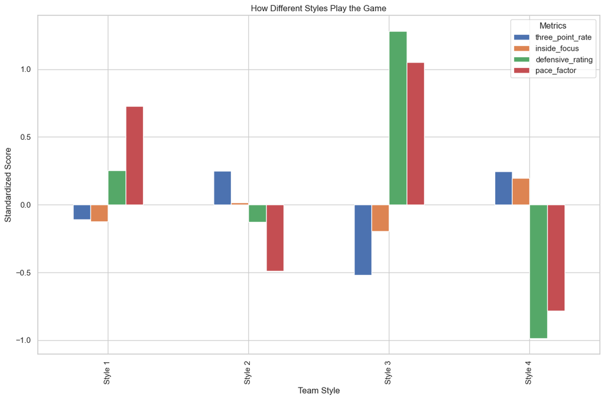

```
Style Characteristics:

Style 1:
- three_point_rate: -0.11
- inside_focus: -0.12
- defensive_rating: 0.25
- pace_factor: 0.73

Style 2:
- three_point_rate: 0.25
- inside_focus: 0.02
- defensive_rating: -0.13
- pace_factor: -0.49

Style 3:
- three_point_rate: -0.52
- inside_focus: -0.19
- defensive_rating: 1.28
- pace_factor: 1.05

Style 4:
- three_point_rate: 0.24
- inside_focus: 0.20
- defensive_rating: -0.99
- pace_factor: -0.78
```

```python
# Compare metrics across clusters
key_metrics = ['three_point_rate', 'inside_focus', 'defensive_rating', 'pace_factor']
cluster_metrics = {}

for cluster_id, center in enumerate(cluster_centers):
    cluster_metrics[f'Style {cluster_id+1}'] = {
        metric: center[idx] for idx, metric in enumerate(key_metrics)
    }

style_comparison = pd.DataFrame(cluster_metrics).T

plt.figure(figsize=(12, 6))
style_comparison.plot(kind='bar')
plt.title('How Different Styles Play the Game')
plt.xlabel('Team Style')
plt.ylabel('Standardized Score')
plt.legend(title='Metrics')
plt.tight_layout()
plt.show()

print("\nStyle Characteristics:")
for style in style_comparison.index:
    print(f"\n{style}:")
    for metric in key_metrics:
        print(f"- {metric}: {style_comparison.loc[style, metric]:.2f}")
```

## Key Finding #2: The Game Has Transformed

Basketball has changed dramatically over the years. Let's examine the key changes through principal components:

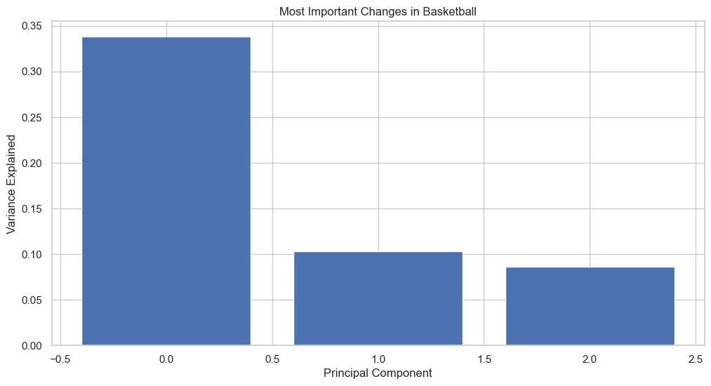

```
Key Changes:
Top 3 components explain 52.7% of changes
```

```python
# Analyze evolution through principal components
explained_variance = analysis_results['pca']['explained_variance_ratio']
top_components = 3

plt.figure(figsize=(12, 6))
plt.bar(range(top_components), explained_variance[:top_components])
plt.title('Most Important Changes in Basketball')
plt.xlabel('Principal Component')
plt.ylabel('Variance Explained')
plt.show()

print("\nKey Changes:")
total_variance = sum(explained_variance[:top_components])
print(f"Top {top_components} components explain {total_variance*100:.1f}% of changes")
```

## Key Finding #3: Innovation Spreads

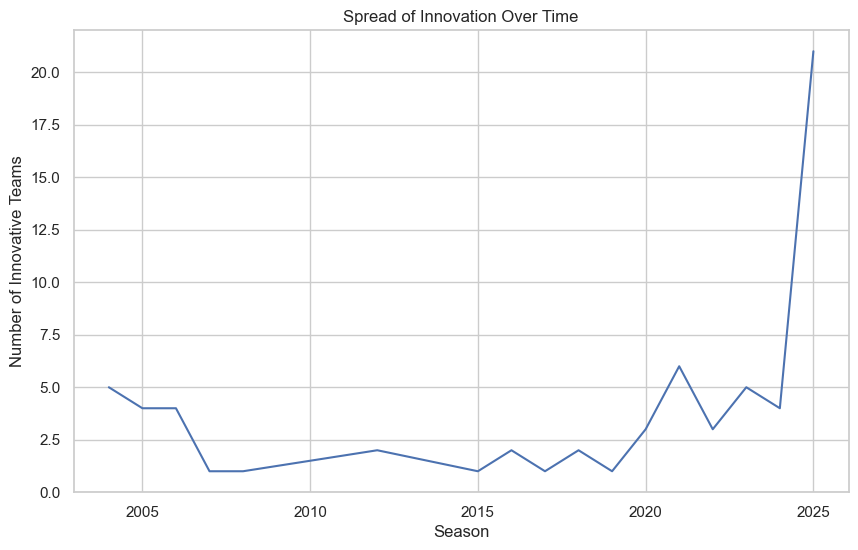

```python
# Analyze outlier patterns
outliers = pd.DataFrame(analysis_results['outliers']['teams'])
outliers_by_season = outliers.groupby('season').size()

plt.figure(figsize=(10, 6))
outliers_by_season.plot()
plt.title('Spread of Innovation Over Time')
plt.xlabel('Season')
plt.ylabel('Number of Innovative Teams')
plt.show()
```

## Key Finding #4: Success Leaves Clues

Teams succeed either by perfecting existing styles or pioneering new ones. Let's analyze the patterns:

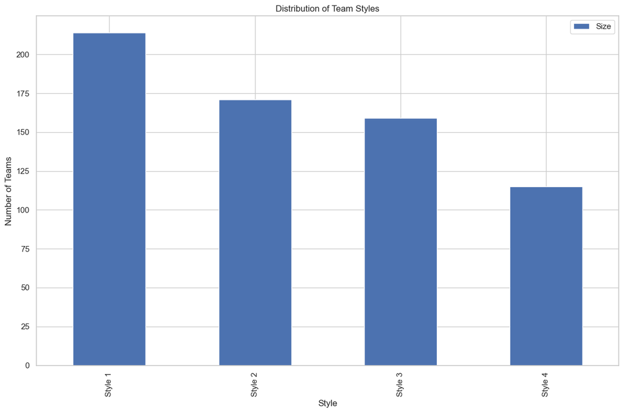

```python
# Compare cluster sizes and stability
cluster_df = pd.DataFrame({
    'Size': cluster_sizes.values(),
    'Style': [f'Style {i+1}' for i in range(len(cluster_sizes))]
})

plt.figure(figsize=(10, 6))
cluster_df.plot(x='Style', y='Size', kind='bar')
plt.title('Distribution of Team Styles')
plt.ylabel('Number of Teams')
plt.tight_layout()
plt.show()
```

## Looking Ahead

Our analysis suggests several trends that will shape basketball's future:

1. **More Innovation**
   - Teams are experimenting more than ever
   - New strategies emerge faster
   - Analytics drive tactical decisions
2. **Faster Evolution**
   - Changes spread quickly through the league
   - Teams adapt more rapidly
   - Strategy cycles are shortening
3. **Data-Driven Decisions**
   - More sophisticated analysis
   - Better performance tracking
   - Clearer strategic insights

## Final Thoughts

Basketball is a game of patterns, but it's also a game that keeps evolving. The teams that succeed are usually the ones that understand this - they either perfect what works now or find what will work next.

Our analysis shows that while there's no single "right way" to play basketball, there are clear patterns in what makes teams successful. Whether it's through revolutionary innovation or masterful execution, the key is commitment to a clear strategic vision.